# Homework #1

See all that stuff above. You should change `theme` and `highlight-style` to fit your own style. You can find them here: https://quarto.org/docs/output-formats/html-themes.html

Seriously, you should start finding your own style, so definitely change them!

## Data

You’ll be working with the following data files:

- `artist_genre.txt`
- `artist_name.csv`
- `artist_net_worth.csv`
- `artist_number_one_hits.csv`
- `artist_studio_albums.csv`
- `artist_top_hits.csv`

The only file that you are going to need to be careful about is the `artist_genre` file – be sure to look at the extension, refer to the notes on I/O, and read the help file!

## Goals

Read the files in and then accomplish the following goals:

### Pre-join Goals

- Use the aggregate function to ensure that each file only contains unique rows.
- If duplicates exist, handle them. You can either de-duplicate them (the `duplicate` function is helpful here) or `aggregate` them to single rows. The choice is yours and yours alone, but be sure to justify your decision.
- Which 5 artists have the greatest net worth?
- Which 15 artists have the most number 1 hits?
- Which 10 artists have the fewest studio albums?

After you have those done, you can join your data frames together.  
**Reading in the Data Tables**

```r
artist_name <- read.csv("~/Desktop/DataWrangling/homework1/artist_name.csv")

artist_net_worth <- read.csv("~/Desktop/DataWrangling/homework1/artist_net_worth.csv")

artist_number_one_hits <- read.csv("~/Desktop/DataWrangling/homework1/artist_number_one_hits.csv")

artist_studio_albums <- read.csv("~/Desktop/DataWrangling/homework1/artist_studio_albums.csv")

artist_top_hits <- read.csv("~/Desktop/DataWrangling/homework1/artist_top_hits.csv")

artist_genre <- read.table(file = "~/Desktop/DataWrangling/homework1/artist_genre.txt", header = TRUE)
```

**Aggregating Artist Name, removing the duplicates**

```r
artist_name_2 <- artist_name

artist_name_2 <- aggregate(Birth_Year ~ Artist,
          data = artist_name_2,
          FUN = unique)
duplicated(artist_name_2)
```

```
 [1] FALSE FALSE FALSE FALSE FALSE FALSE FALSE FALSE FALSE FALSE FALSE FALSE
[13] FALSE FALSE FALSE FALSE FALSE FALSE FALSE FALSE FALSE FALSE FALSE FALSE
[25] FALSE FALSE FALSE FALSE FALSE FALSE FALSE FALSE FALSE FALSE FALSE FALSE
[37] FALSE FALSE FALSE FALSE FALSE FALSE FALSE FALSE FALSE FALSE FALSE FALSE
[49] FALSE FALSE FALSE FALSE FALSE FALSE FALSE FALSE FALSE FALSE FALSE FALSE
[61] FALSE
```

**Aggregating Artist Net Worth, removing duplicates**

```r
artist_net_worth_2 <- artist_net_worth
artist_net_worth_2 <- aggregate(net_worth_millions ~ Artist,
                                data = artist_net_worth_2,
                                FUN = unique)
```

**Aggregating Artist Genre, removing duplicates**

```r
artist_genre_2 <- artist_genre
artist_genre_2 <- aggregate(genre ~ Artist,
                            data = artist_genre_2,
                            FUN = unique)
```

**Aggregating Artist number one hits, removing duplicates**

```r
artist_number_one_hits_2 <- artist_number_one_hits
artist_number_one_hits_2 <- aggregate(number_one_hits ~ artist,
                            data = artist_number_one_hits_2,
                            FUN = unique)
```

**Aggregating Artist Studio Albums, removing duplicates**

```r
artist_studio_albums_2 <- artist_studio_albums
artist_studio_albums_2 <- aggregate(studio_albums ~ Artist,
                                    data = artist_studio_albums_2,
                                    FUN = unique)
```

**Aggregating Top Hits by Artist, removing duplicates**

```r
artist_top_hits_2 <- artist_top_hits
artist_top_hits_2 <- aggregate(cbind(Top_Hit, Year) ~ Artist,
                               data = artist_top_hits_2,
                               FUN = unique)
```

**Sorting Artist by their Net Worth in Millions to determine the top 5 artists w/ highest net worth**

```r
artist_net_worth_2$net_worth_millions <-
  as.numeric(gsub("\\$", "", x = artist_net_worth_2$net_worth_millions))
sort(artist_net_worth_2$net_worth_millions, decreasing = TRUE)
```

```
 [1] 1500 1500  900  900  850  750  700  550  500  440  410  400  400  350  350
[16]  330  320  320  315  300  300  300  300  300  285  260  250  250  230  230
[31]  220  200  200  200  200  190  180  175  175  160  150  150  150  130  120
[46]  110  100   80   75   75   75   70   70   60   40   30   25   20   20   16
[61]   10
```

```r
artist_net_worth_2 <- artist_net_worth_2[order(artist_net_worth_2$net_worth_millions,
                             decreasing = TRUE),]
artist_net_worth_2[1:5, ]
```

```
               Artist net_worth_millions
25              Jay-Z               1500
54        The Beatles               1500
1                ABBA                900
58 The Rolling Stones                900
38            Madonna                850
```

- Which 5 artists have the greatest net worth?
1. Jay-Z ($1500M)
2. The Beatles ($1500M)
3. ABBA ($900M)
4. The Rolling Stones ($900M)
5. Madonna ($850M)

**Sorting Artists by their #1 Hits to determine top 15 artists.**

```r
artist_number_one_hits_2 <- artist_number_one_hits_2[order(artist_number_one_hits_2$number_one_hits,
                             decreasing = TRUE), ]
artist_number_one_hits_2[1:15, ]
```

```
               artist number_one_hits
54        The Beatles              20
39       Mariah Carey              19
19      Elvis Presley              18
47            Rihanna              14
41    Michael Jackson              13
38            Madonna              12
61    Whitney Houston              11
51      Stevie Wonder              10
32         Katy Perry               9
15              Drake               8
58 The Rolling Stones               8
12         Bruno Mars               7
52       Taylor Swift               7
16         Ed Sheeran               6
18         Elton John               6
```

- Which 15 artists have the most number 1 hits?
1. The Beatles (20)
2. Mariah Carey (19)
3. Elvis Presley (18).
4. Rihanna (14)
5. Michael Jackson(13) )
6. Madonna (12)
7. Whitney Houston (11)
8. Stevie Wonder (10)
9. Katy Perry (9)
10. Drake (8)
11. The Rolling Stones (8)
12. Bruno Mars(7)
13. Taylor Swift (7)
14. Ed Sheeran (6)
15. Elton John (6)

**Which artists have the fewest studio albums?**

```r
artist_studio_albums_2 <- artist_studio_albums_2[order(artist_studio_albums_2$studio_albums,
                             decreasing = FALSE), ]
artist_studio_albums_2[1:10, ]
```

```
                 Artist studio_albums
8         Billie Eilish             1
37                Lorde             2
56 The Notorious B.I.G.             2
2                 Adele             3
12           Bruno Mars             3
26         Jimi Hendrix             3
42              Nirvana             3
48            Sam Smith             3
24      Imagine Dragons             4
31    Justin Timberlake             4
```

- Which 10 artists have the fewest studio albums?
  1. Billie Eillish (1)
  2. Lorde (2)
  3. The Notorious B.I.G (2)
  4. Adele (3)
  5. Bruno Mars (3)
  6. Jimi Hendrix (3)
  7. Nirvana (3)
  8. Sam Smith (3)
  9. Imagine Dragons (4)
  10. Justin Timerlake (4)

### Post-join Goals

- Create variables to capture the following ideas:
  - How long has the artist been around? You can just use their birth year.
  - Something to capture each artist’s net worth per studio album.
- Plot net worth per studio album, the “been around” variable, and genre. There should be points and colors here.

For all tasks comment your code and explain what you found!

**Join Tables**

```r
merge_artist_1 <- merge(x = artist_genre_2,
                        y = artist_name_2,
                        by = "Artist",
                        all.x = TRUE)
merge_artist_2 <- merge(x = artist_net_worth_2,
                        y = artist_studio_albums_2,
                        by = "Artist",
                        all.x = TRUE)
merge_artist_3 <- merge(x = merge_artist_1,
                        y= merge_artist_2,
                        by = "Artist",
                        all.x = TRUE)

# Need to change column names of Artist Column in
# Number One Hits and Top Hits to make sense & merge into the complete_artist_data data frame

colnames(artist_number_one_hits_2)[colnames(artist_number_one_hits_2) == "artist"] = "Artist"
colnames(artist_top_hits_2)[colnames(artist_top_hits_2) == "Year"] = "Top_Hit_Release_Year"

merge_artist_4 <- merge(x = artist_top_hits_2,
                        y = artist_number_one_hits_2,
                        by = "Artist",
                        all.x = TRUE)
complete_artist_data <- merge(x = merge_artist_3,
                              y = merge_artist_4,
                              by = "Artist",
                              all.x = TRUE)
```

**Calculate how long the artist has ‘been around’ or their age Column Name will be Artist Been Around in Complete Artist Data**

```r
library(dplyr)
current_year <- as.numeric(format(Sys.Date(),"%Y"))
current_year
```

```
[1] 2024
```

```r
artist_been_around <- current_year - complete_artist_data$Birth_Year

artist_been_around <- data.frame(artist_name_2$Artist, artist_been_around)

colnames(artist_been_around)[colnames(artist_been_around) == "artist_name_2.Artist"] = "Artist"

complete_artist_data <- merge(x = complete_artist_data,
                              y = artist_been_around,
                              by = "Artist",
                              all.x = TRUE)
```

**Something to capture each artist’s net worth per studio album.**

```r
net_worth_studio_album <- merge_artist_2$net_worth_millions / merge_artist_2$studio_albums
net_worth_studio_album <- round(net_worth_studio_album, digits = 2)
#Add Net Worth per Studio Album to Complete Artist Data Set
complete_artist_data$net_worth_studio_album = net_worth_studio_album
```

- Plot net worth per studio album, the “been around” variable, and genre. There should be points and colors here.

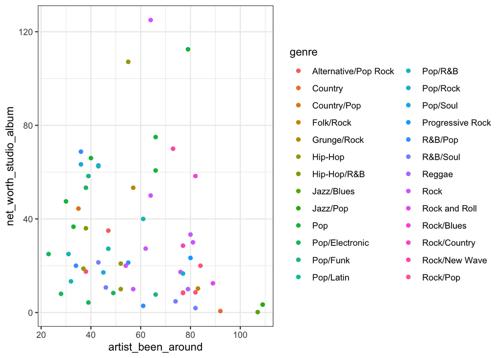

```r
library(ggplot2)

ggplot(complete_artist_data, aes(x = artist_been_around,
           y = net_worth_studio_album,
           color = genre)) +
      geom_point() +
      theme_bw()
```